# EFBMC Example

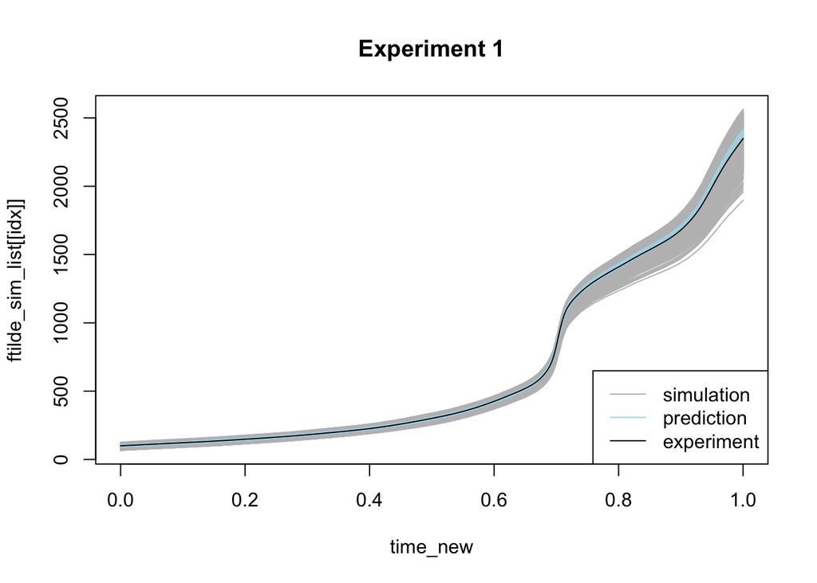

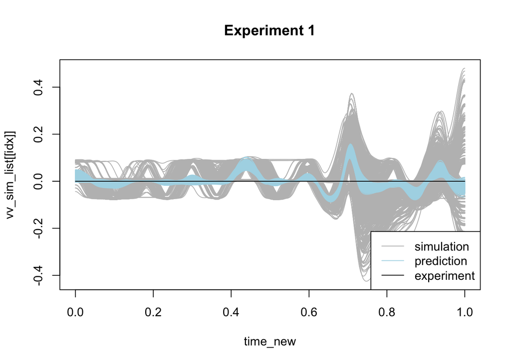

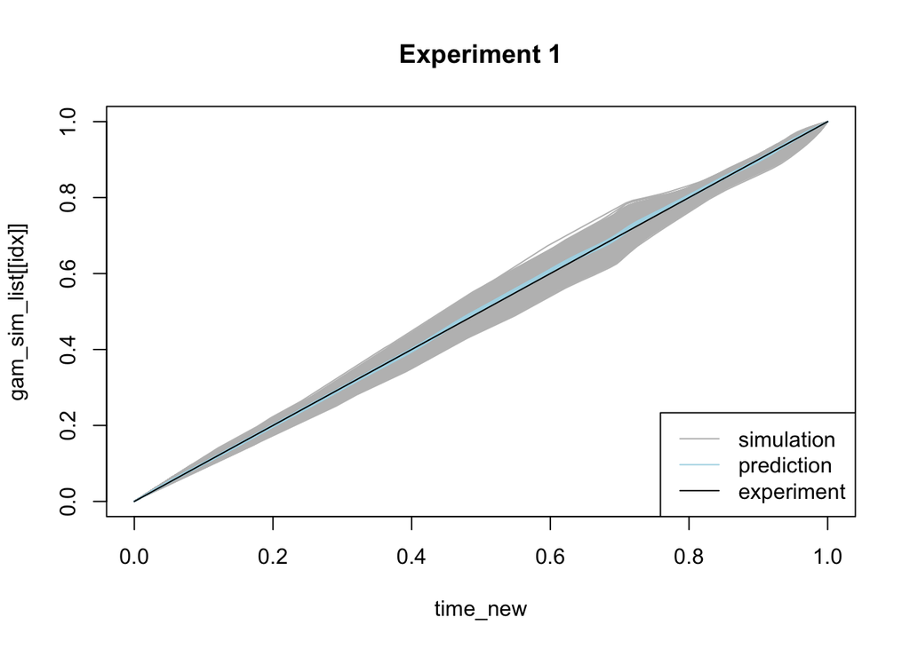

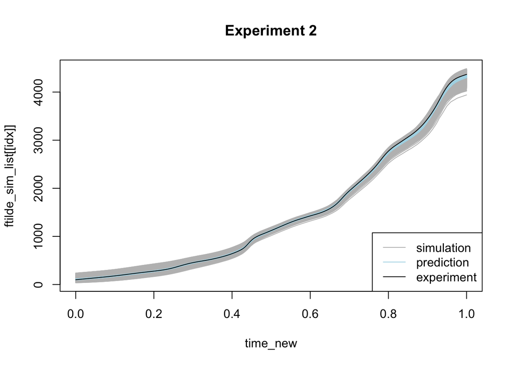

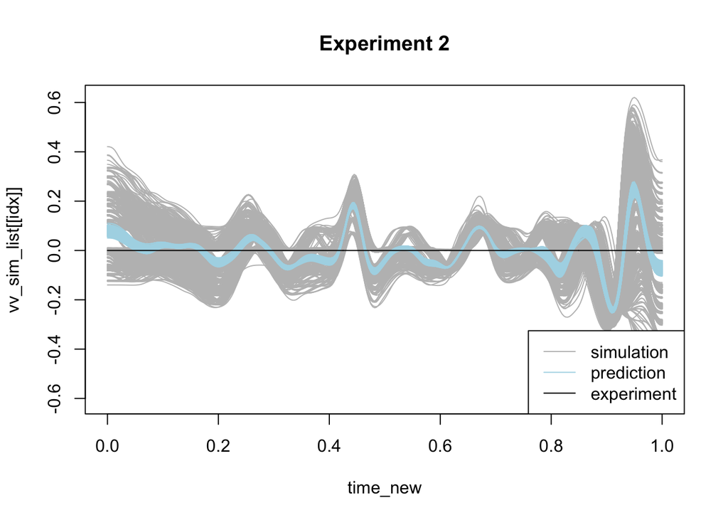

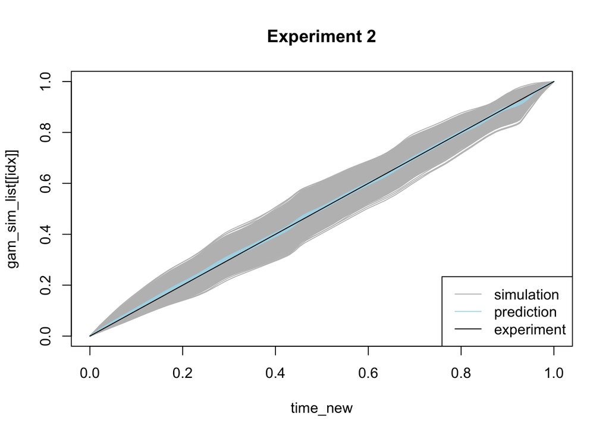

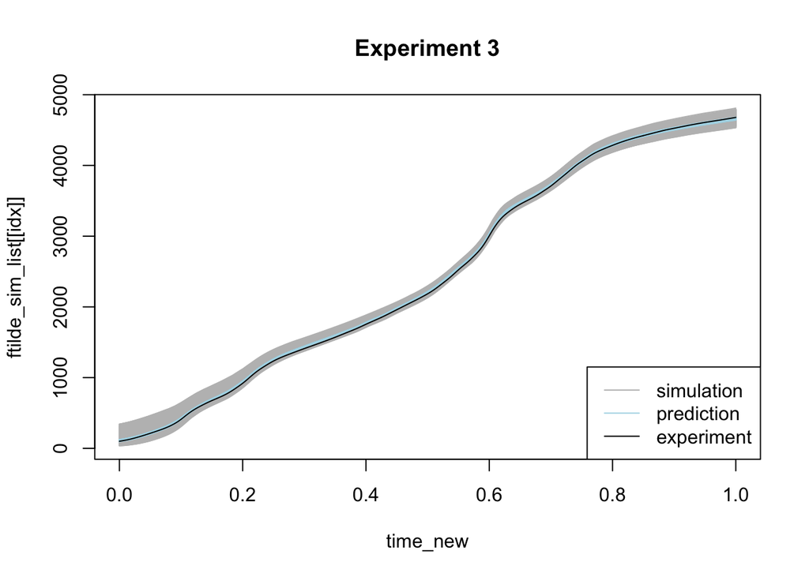

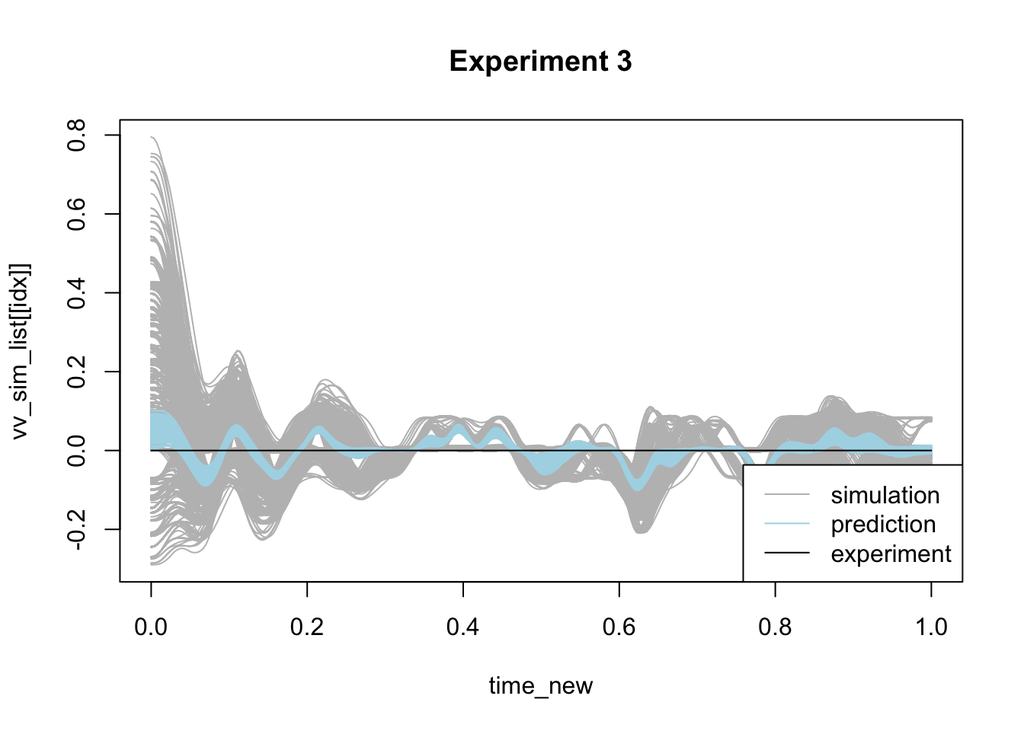

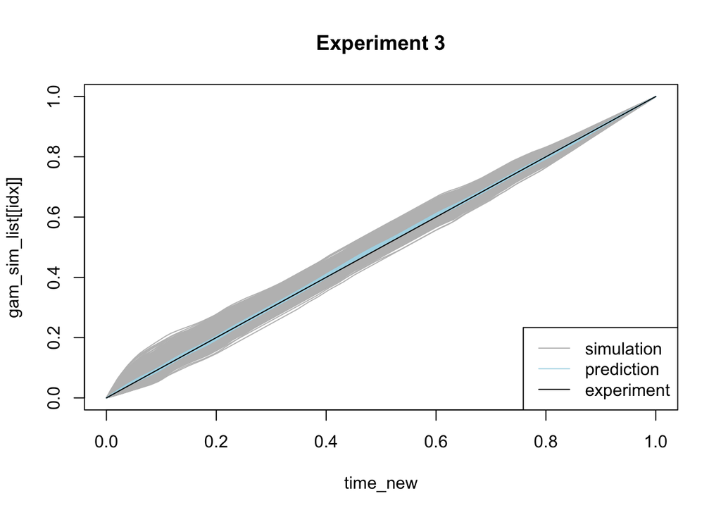

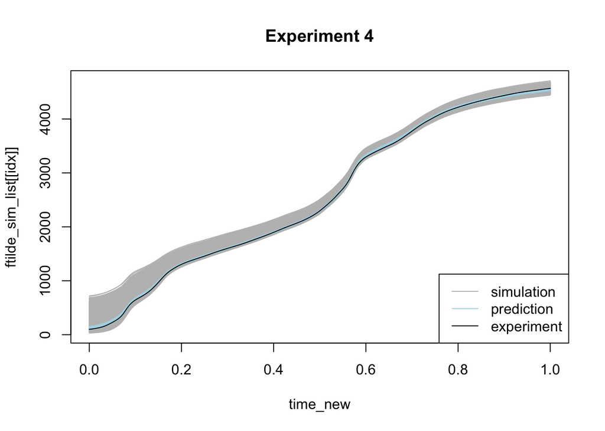

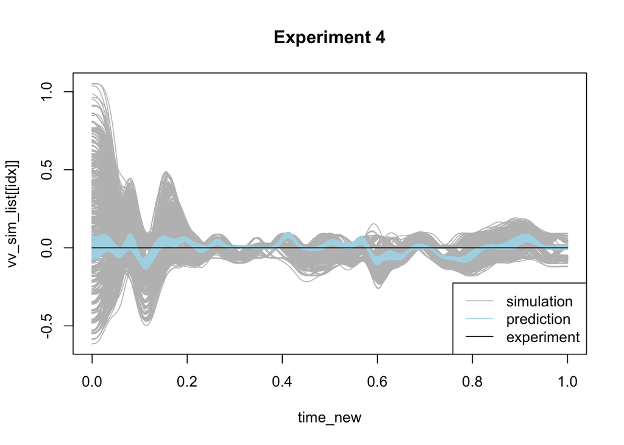

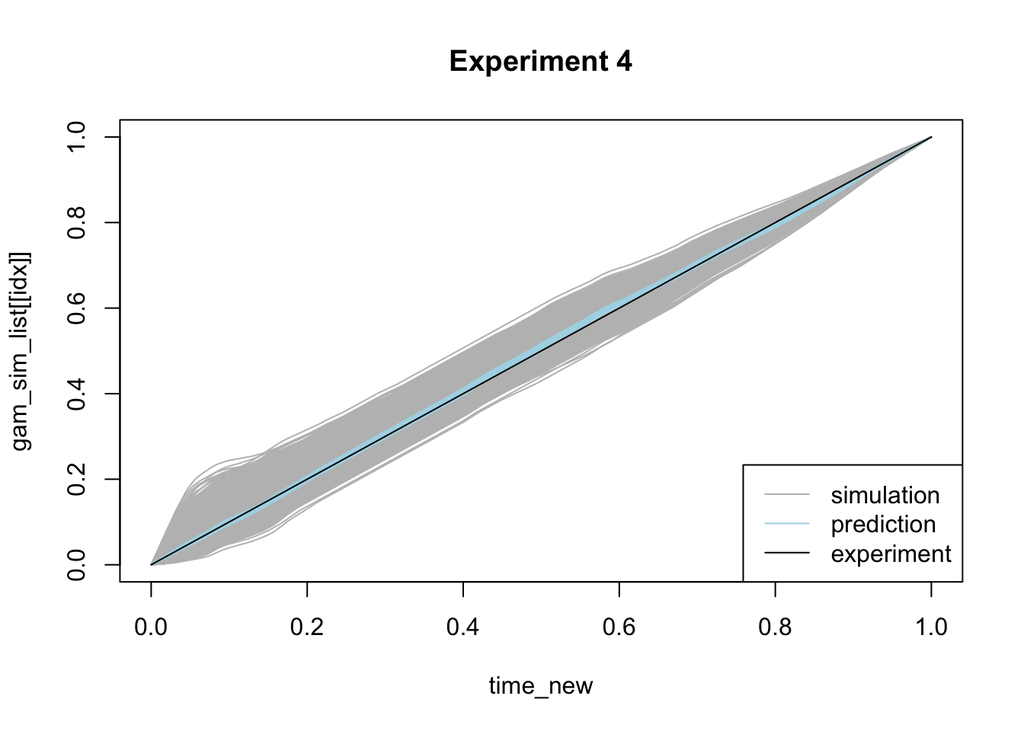

```r
for (idx in 1:nexp) {
  matplot(
    time_new,
    ftilde_sim_list[[idx]],
    type = "l",
    col = "gray",
    lty = 1, main=sprintf("Experiment %d",idx)
  )
  matplot(
    time_new,
    t(ftilde_pred_obs[[idx]]),
    type = "l",
    col = "lightblue",
    lty = 1,
    add = TRUE
  )
  lines(time_new, ftilde_obs_list[[idx]], col = "black")
  legend(
    "bottomright",
    legend = c("simulation", "prediction", "experiment"),
    col = c("gray", "lightblue", "black"),
    lty = 1
  )

  matplot(
    time_new,
    vv_sim_list[[idx]],
    type = "l",
    col = "gray",
    lty = 1, main=sprintf("Experiment %d",idx)
  )
  matplot(
    time_new,
    t(vv_pred_obs[[idx]]),
    type = "l",
    col = "lightblue",
    lty = 1,
    add = TRUE
  )
  lines(time_new, vv_obs_list[[idx]], col = "black")
  legend(
    "bottomright",
    legend = c("simulation", "prediction", "experiment"),
    col = c("gray", "lightblue", "black"),
    lty = 1
  )

  matplot(
    time_new,
    gam_sim_list[[idx]],
    type = "l",
    col = "gray",
    lty = 1, main=sprintf("Experiment %d",idx)
  )
  matplot(
    time_new,
    gam_pred_obs[[idx]],
    type = "l",
    col = "lightblue",
    lty = 1,
    add = TRUE
  )
  lines(time_new, gam_obs_list[[idx]], col = "black")
  legend(
    "bottomright",
    legend = c("simulation", "prediction", "experiment"),
    col = c("gray", "lightblue", "black"),
    lty = 1
  )
}
```

We then combine the outputs of the emulators via composition to look at in the original data space

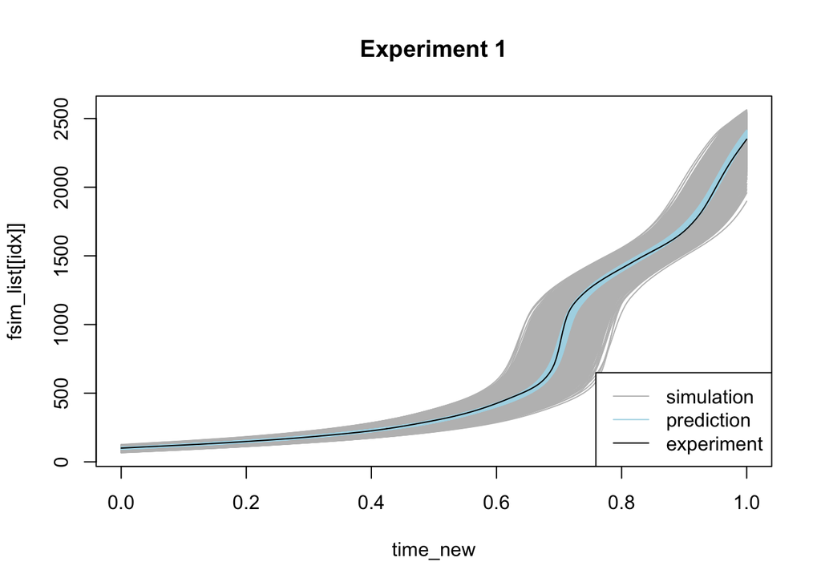

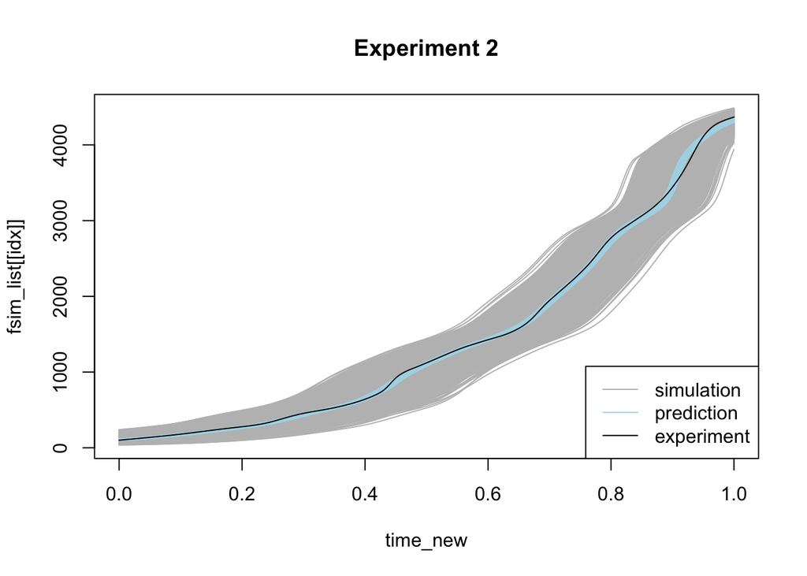

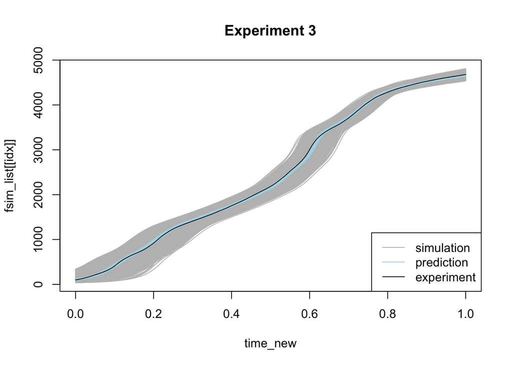

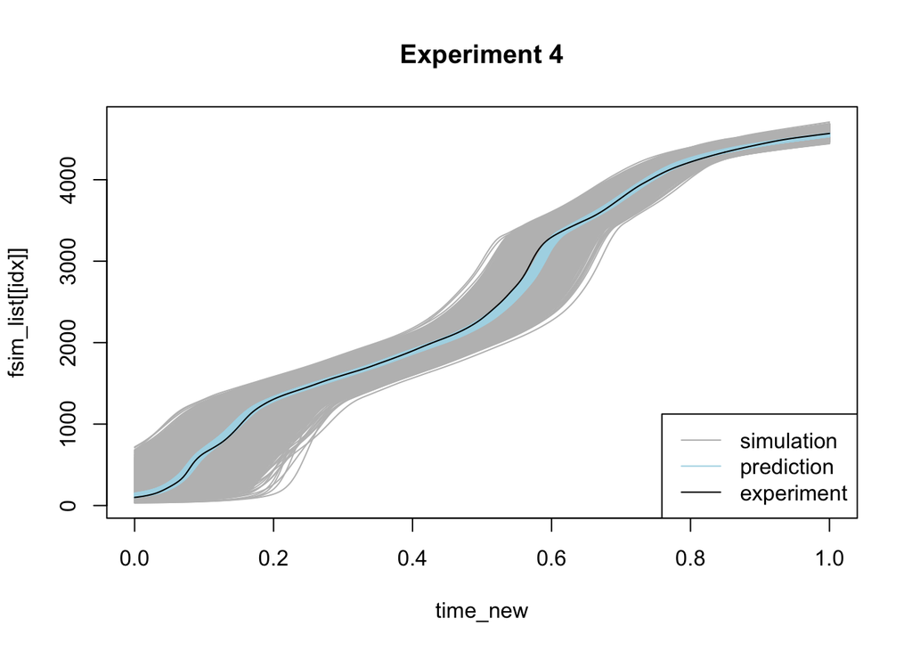

```r
obspred_all_list = vector(mode = "list", length = setup$nexp)
for (j in 1:nexp){
  obspred = matrix(0, M, length(uu))
  for (i in 1:length(uu)) {
    obspred[, i] = warp_f_gamma(ftilde_pred_obs[[j]][i, ], time_new, invertGamma(gam_pred_obs[[j]][, i]))
  }
  obspred_all_list[[j]] = obspred
}

for (idx in 1:nexp) {
  matplot(
      time_new,
      fsim_list[[idx]],
      type = "l",
      col = "gray",
      lty = 1, main=sprintf("Experiment %d",idx)
    )
  matplot(
    time_new,
    obspred_all_list[[idx]],
    type = "l",
    col = "lightblue",
    lty = 1,
    add = TRUE
  )
  lines(time_new, f_exp_list[[idx]], col = "black")
  legend(
    "bottomright",
    legend = c("simulation", "prediction", "experiment"),
    col = c("gray", "lightblue", "black"),
    lty = 1
  )
}
```

# Sensitivity Analysis

We can also perform sensitivity analysis on the surrogate through `mvBayes` by doing the following. The BASS emulator has a closed form sobol indices and we will utilize that. `mvBayes` also provides the ability to monte carlo to determine the sobol indices.

First we will look at the amplitude surrogate

```
## Start ##------ Thu Jun  4 13:14:43 2026 ------##
## Integrating ##------ Thu Jun  4 13:14:43 2026 ------##
## Shuffling ##------ Thu Jun  4 13:14:49 2026 ------##
## Finish ##------ Thu Jun  4 13:14:49 2026 ------##
```

```
## Start ##------ Thu Jun  4 13:14:49 2026 ------##
## Integrating ##------ Thu Jun  4 13:14:49 2026 ------##
## Shuffling ##------ Thu Jun  4 13:14:57 2026 ------##
## Finish ##------ Thu Jun  4 13:14:57 2026 ------##
```

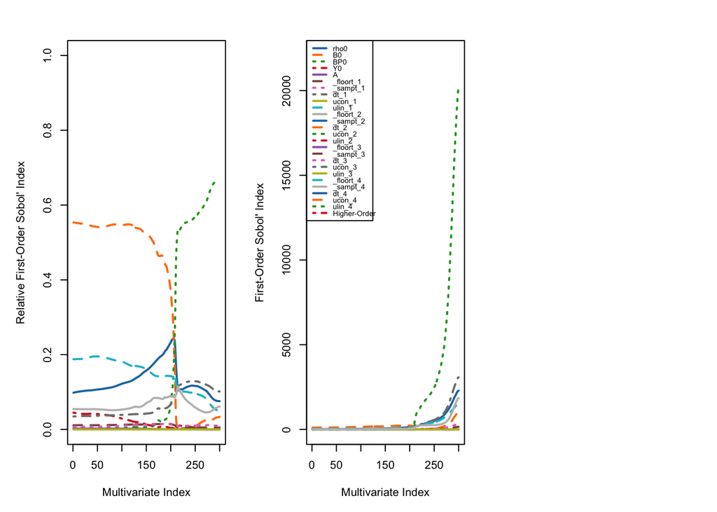

```
## Start ##------ Thu Jun  4 13:14:57 2026 ------##
## Integrating ##------ Thu Jun  4 13:14:57 2026 ------##
## Shuffling ##------ Thu Jun  4 13:15:08 2026 ------##
## Finish ##------ Thu Jun  4 13:15:08 2026 ------##
```

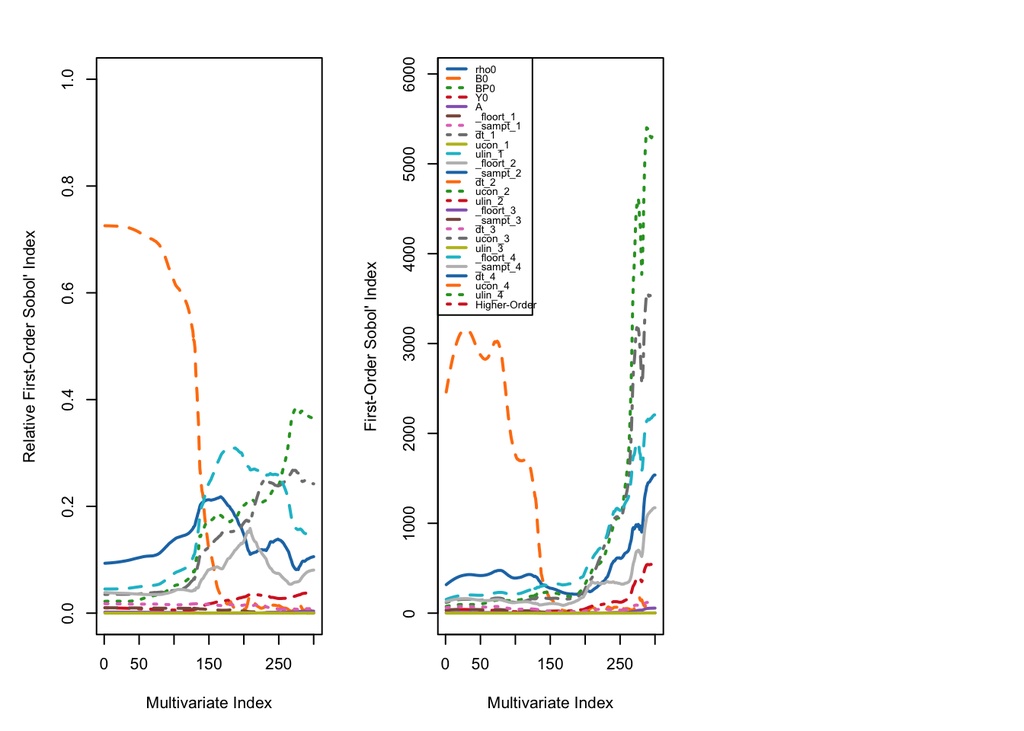

```
## Start ##------ Thu Jun  4 13:15:08 2026 ------##
## Integrating ##------ Thu Jun  4 13:15:08 2026 ------##
## Shuffling ##------ Thu Jun  4 13:15:24 2026 ------##
## Finish ##------ Thu Jun  4 13:15:24 2026 ------##
```

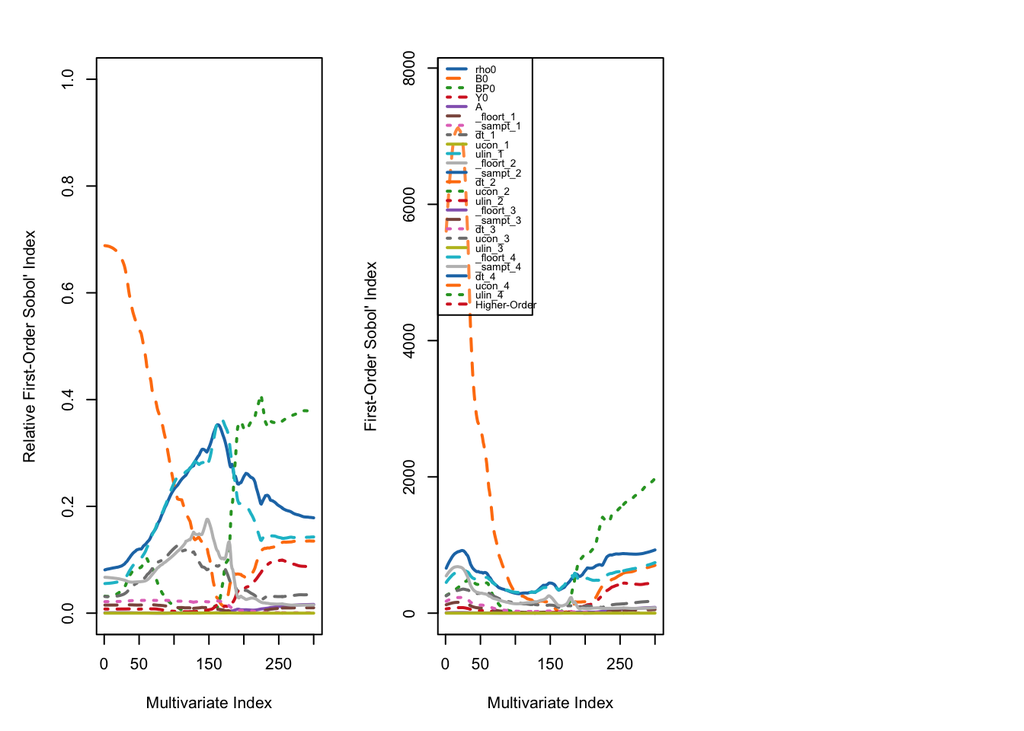

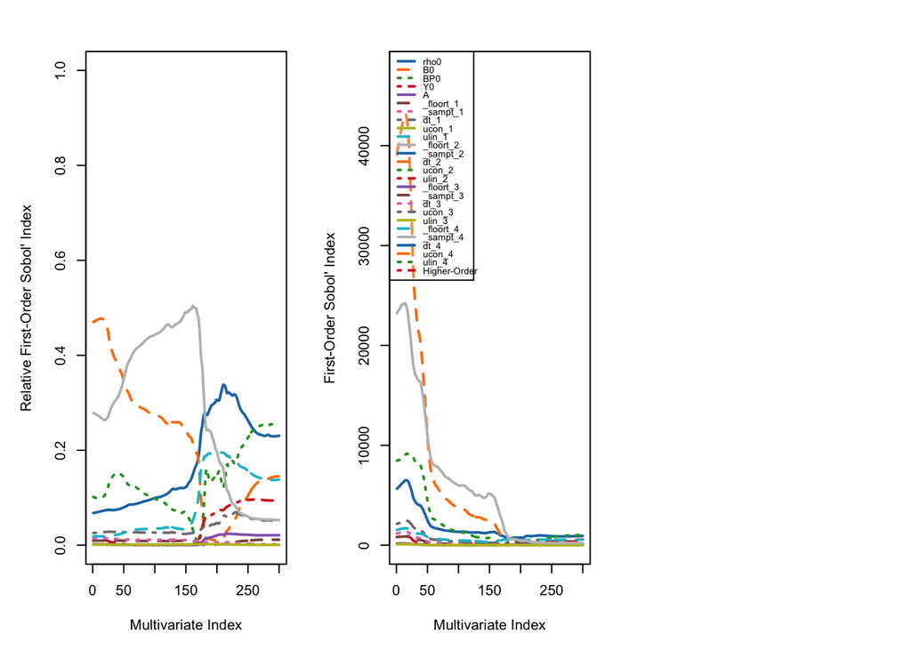

```r
for (idx in 1:nexp) {
  emu_ftilde[[idx]] = mvSobol(emu_ftilde[[idx]])
  plot(emu_ftilde[[idx]], labels=input_names)
}
```

Next the phase surrogate

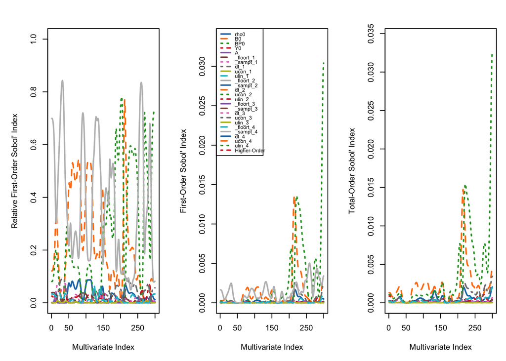

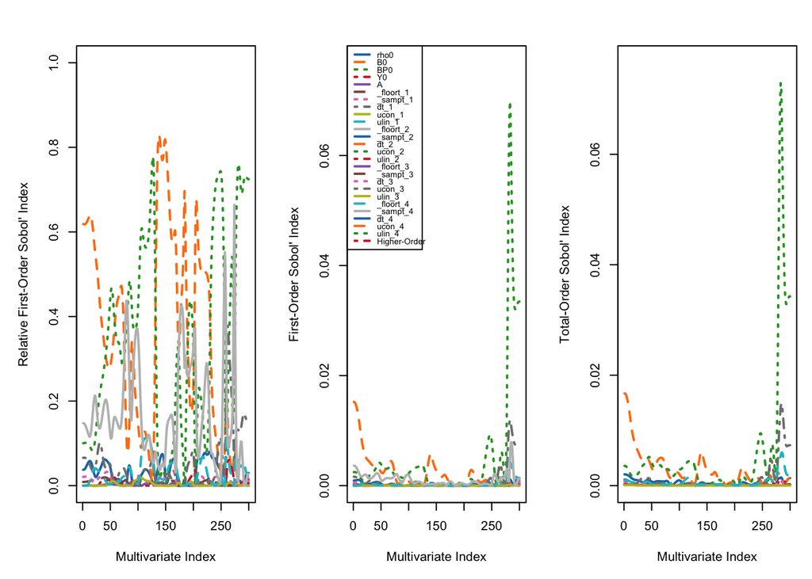

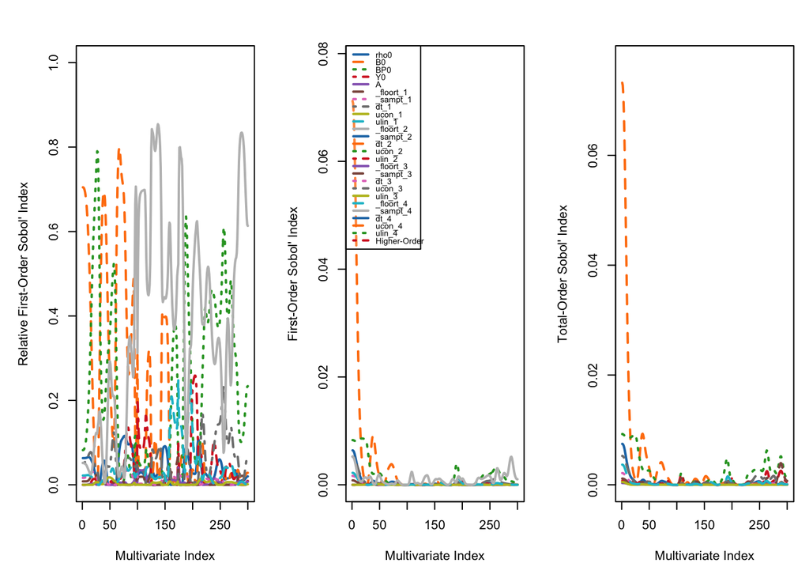

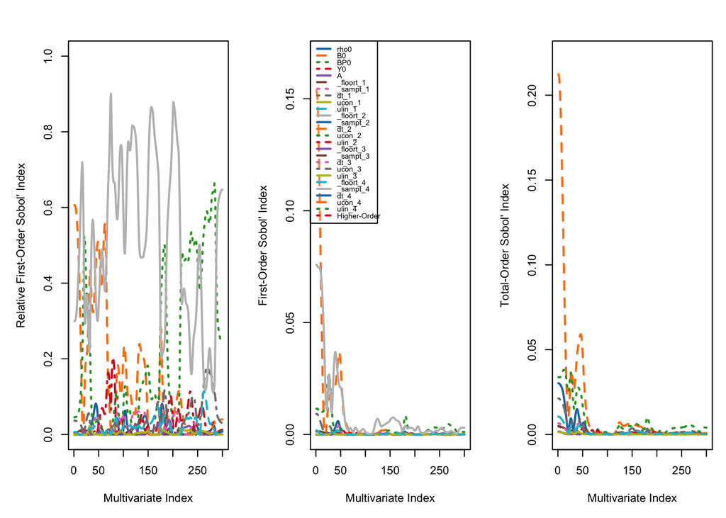

```r
for (idx in 1:nexp) {
  emu_vv[[idx]] = mvSobol(emu_vv[[idx]], nMC=2^9)
  plot(emu_vv[[idx]], labels=input_names)
}
```

We can also look at sensitivity as a functional boxplot or waterfall plot

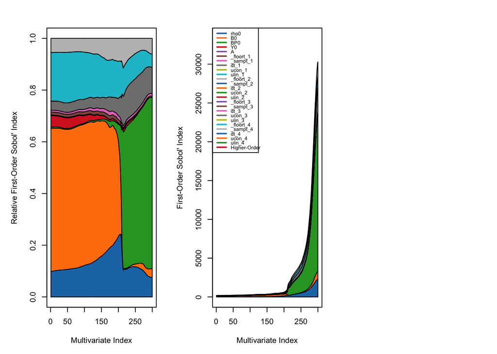

```r
  plot(emu_ftilde[[1]], labels=input_names, waterfall=TRUE)
```